# Psychoinformatics - Week 14 (Exercises)

by 賴雅嵋 (d07227201@ntu.edu.tw)

## 1 進一步研究CNN (6 points)

### 1.1 為何ResNet50會判斷小女孩照片為ping-pong_bal, bubble, or Band_Aid? (4 points)

```python
import numpy as np
from tensorflow.keras.applications.resnet50 import ResNet50
from keras.preprocessing import image
from tensorflow.keras.applications.resnet50 import preprocess_input, decode_predictions
```

```python
model = ResNet50(weights='imagenet')

img_path = 'girl.jpg'
img = image.load_img(img_path, target_size=(224, 224)) # Or use cv2.resize to resize images
x = image.img_to_array(img)
x = np.expand_dims(x, axis=0)
x = preprocess_input(x)

preds = model.predict(x)
# decode the results into a list of tuples (class, description, probability)
# (one such list for each sample in the batch)
print('Predicted:', decode_predictions(preds, top=3)[0])
```

```
Predicted: [('n03942813', 'ping-pong_ball', 0.17623469), ('n09229709', 'bubble', 0.10817197), ('n02786058', 'Band_Aid', 0.08954375)]
```

```python
print('Predicted:', decode_predictions(preds, top=10)[0])
```

```
Predicted: [('n03942813', 'ping-pong_ball', 0.17623469), ('n09229709', 'bubble', 0.10817197), ('n02786058', 'Band_Aid', 0.08954375), ('n07615774', 'ice_lolly', 0.040802773), ('n07742313', 'Granny_Smith', 0.036095064), ('n04370456', 'sweatshirt', 0.031320963), ('n03929660', 'pick', 0.02691468), ('n04…
```

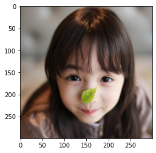

```python
import matplotlib.pyplot as plt
img=plt.imread('girl.jpg')
plt.imshow(img)
```

1. ping-pong_bal和bubble可能因為是model將比較圓的特徵（如：眼睛、臉或葉子）辨識成偏向圓形或球形的類別；aid band則可能是model將鼻上的葉子辨識成是皮膚上的貼片。--> 這可能是某些特徵太明顯，勝過人臉，所以model的top 3，前三高機率的判斷都不是人臉。不過，列出top 10也還是沒有人臉，而是與圖上特徵有知覺相似性的其他東西，所以還有另一個可能是這model根本沒有人臉相關的knowlegde。
2. 用human, people, (wo)man, (fe)male, adult, child, baby, infant, boy, girl...等關鍵字直接搜尋imagenet dataset的labels(https://gist.github.com/yrevar/942d3a0ac09ec9e5eb3a#file-imagenet1000_clsidx_to_labels-txt) ，結果都沒有，所以很可能這個模型並沒有用人臉作為training data。
3. 2021三月ImageNet團隊發表的文章(https://arxiv.org/pdf/2103.06191.pdf) 中有提到"...only 3 people categories in the 1000 categories..."，亦即997/1000的類別都不是人，訓練階段接觸到人臉的機會微乎其微；進一步檢視那3個類別，分別是"cuba diver, bridegroom, and baseball player"，重點也不在人臉。這都支持第2點的推測。此外，這篇文章主旨其實是團隊基於隱私模糊了dataset中出現的人臉（但不至於影響整體辨識準確度），所以未來用這個dataset去訓練的model，就更沒有遇到人臉材料的機會了。

### 1.2 請展示有別人pre-trained好的Keras model可以成功辨認girl.jpg為人臉 (4 points)

```python
# Please write your codes here
#!pip install keras-vggface
#!pip install keras_applications
```

## 1.2.1 使用MTCNN model進行facial detection

```python
#!pip3 install mtcnn
```

```python
from matplotlib import pyplot as plt
from mtcnn.mtcnn import MTCNN

image = plt.imread('girl.jpg')

detector = MTCNN()
faces = detector.detect_faces(image)
for face in faces:
    print(face)
```

```
{'box': [80, 85, 154, 186], 'confidence': 0.9886658191680908, 'keypoints': {'left_eye': (121, 162), 'right_eye': (195, 163), 'nose': (160, 208), 'mouth_left': (129, 230), 'mouth_right': (184, 230)}}
{'box': [11, 204, 65, 85], 'confidence': 0.7956100106239319, 'keypoints': {'left_eye': (31, 242), 'right_eye': (61, 240), 'nose': (46, 258), 'mouth_left': (35, 275), 'mouth_right': (57, 274)}}
```

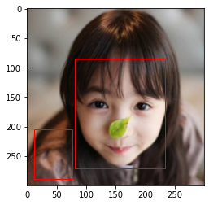

```python
from matplotlib.patches import Rectangle
%matplotlib inline

def highlight_faces(image_path, faces):
    image = plt.imread(image_path)
    plt.imshow(image)
    ax = plt.gca()

    for face in faces:
        x, y, width, height = face['box']
        face_border = Rectangle((x, y), width, height, fill=False, color='red')
        ax.add_patch(face_border)
    plt.show()
highlight_faces('girl.jpg', faces)
```

### 使用MTCNN model進行face detection，檢測到像人臉的東西就會丟出一個python字典，包含box, confidence, & keypoints。其中keypoints就包含了重要特徵像是雙眼、鼻子、嘴角等等。 結果很有趣，MTCNN從girl.jpg偵測到兩張臉，如紅框所示，顯示MTCNN的人臉偵測規則仍有可能誤判，這時可以細看confidence數值得知何者為人臉的機率較高(0.99 vs 0.80)。

```
{'box': [80, 85, 154, 186], 'confidence': 0.9886658191680908, 'keypoints': {'left_eye': (121, 162), 'right_eye': (195, 163), 'nose': (160, 208), 'mouth_left': (129, 230), 'mouth_right': (184, 230)}}
```

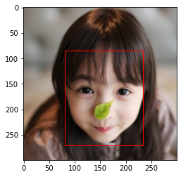

```python
from matplotlib import pyplot as plt
from mtcnn.mtcnn import MTCNN

image = plt.imread('girl.jpg')

detector = MTCNN(steps_threshold=[0.7, 0.8, 0.85])
faces = detector.detect_faces(image)
for face in faces:
    print(face)

from matplotlib.patches import Rectangle
%matplotlib inline

def highlight_faces(image_path, faces):
    image = plt.imread(image_path)
    plt.imshow(image)
    ax = plt.gca()

    for face in faces:
        x, y, width, height = face['box']
        face_border = Rectangle((x, y), width, height, fill=False, color='red')
        ax.add_patch(face_border)
    plt.show()
highlight_faces('girl.jpg', faces)
```

### 如果直接設定好人臉判斷的閾值detector = MTCNN(steps_threshold=[0.7, 0.8, 0.85])，就可以直接過濾掉low confidence的false alarms。如上圖，只剩一個紅框框。

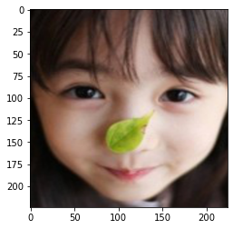

```python
from numpy import asarray
from PIL import Image
def extract_face_from_image(image_path, required_size=(224, 224)):
    image = plt.imread(image_path)
    detector = MTCNN()
    faces = detector.detect_faces(image)
    face_images = []
    for face in faces:
        x1, y1, width, height = face['box']
        x2, y2 = x1 + width, y1 + height
        face_boundary = image[y1:y2, x1:x2]
        face_image = Image.fromarray(face_boundary)
        face_image = face_image.resize(required_size)
        face_array = asarray(face_image)
        face_images.append(face_array)
    return face_images
extracted_face = extract_face_from_image('girl.jpg')
plt.imshow(extracted_face[0])
plt.show()
```

用extract_face_from_image()從girl.jpg中擷取臉部。

## 1.2.2 以keras-vggface做facial recognition

```python
from keras_vggface.vggface import VGGFace
from keras_vggface import utils

model1 = VGGFace()

img = image.load_img('girl.jpg', target_size=(224, 224))
x = image.img_to_array(img)
x = np.expand_dims(x, axis=0)
x = utils.preprocess_input(x)
preds = model1.predict(x)
print('Predicted:', utils.decode_predictions(preds))
```

```
Predicted: [[["b'Hye-kyo_Song'", 0.26114726], ["b'Doona_Bae'", 0.047403585], ["b'Tatsuya_Fujiwara'", 0.036788404], ["b'Michelle_Krusiec'", 0.032255102], ["b'Crystal_Bernard'", 0.026461203]]]
```

```python
model2 = VGGFace(model='resnet50')

img = image.load_img('girl.jpg', target_size=(224, 224))
x = image.img_to_array(img)
x = np.expand_dims(x, axis=0)
x = utils.preprocess_input(x, version=2)
preds = model2.predict(x)
print('Predicted:', utils.decode_predictions(preds))
```

```
Predicted: [[["b' Ayaka_Kikuchi'", 0.1101359], ["b' Kanako_Enomoto'", 0.10703586], ["b' Ayumi_Ishida'", 0.099301085], ["b' Aika_Oota'", 0.06191435], ["b' Haruna_Kojima'", 0.03340035]]]
```

### 以Oxford的keras-vggface(https://github.com/rcmalli/keras-vggface), which was pretrained by VGG-Face Dataset，可以辨識圖片中的臉像哪個名人： model1 based on VGG16架構，得到和girl.jpg最像的是宋慧喬。 model2 based on ResNnt50架構，得到和girl.jpg最像的是菊地彩香。

```python
model1 = VGGFace()

img = image.load_img('house.jpg', target_size=(224, 224))
x = image.img_to_array(img)
x = np.expand_dims(x, axis=0)
x = utils.preprocess_input(x)
preds = model1.predict(x)
print('Predicted:', utils.decode_predictions(preds))
```

```
Predicted: [[["b'Riley_Steele'", 0.011531541], ["b'Caitlin_FitzGerald'", 0.01006658], ["b'Lucy_Davis'", 0.007689113], ["b'Adina_Porter'", 0.0070899515], ["b'Chelsea_Hobbs'", 0.0059163757]]]
```

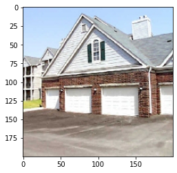

```python
img_house=plt.imread('house.jpg')
plt.imshow(img_house)
```

### 由於這個vggface的training dataset是人臉，所以如果把house丟進model1裡面跑，也會硬是跑出幾位名人，而這幾位google到的照片多半是長髮，所以可能是這樣和A字形屋頂的知覺特徵相近。不過其實預測的機率已經低到不行(top 1也只有1%)，可能顯示這個model還算是能有效分辨人臉與非人臉。